# employee_retention

### Ensemble Modelling

I developed an ensemble model using a stacking technique, incorporating regression for the top layer, to amalgamate diverse individual models. This approach demanded rigorous experimentation, involving careful amalgamation of models, to pinpoint the optimal ensemble. The results yielded exceptional outcomes.

Following a thorough assessment, we detected a remarkable enhancement in the roc_auc metric, signifying a substantial improvement in the predictive precision of our ensemble model. The accompanying chart furnishes comprehensive insights into our discoveries, graphically showcasing the magnitude of the performance enhancement achieved. This accomplishment marks a pivotal stride in tackling employee attrition systematically, while also refining our predictive proficiencies.

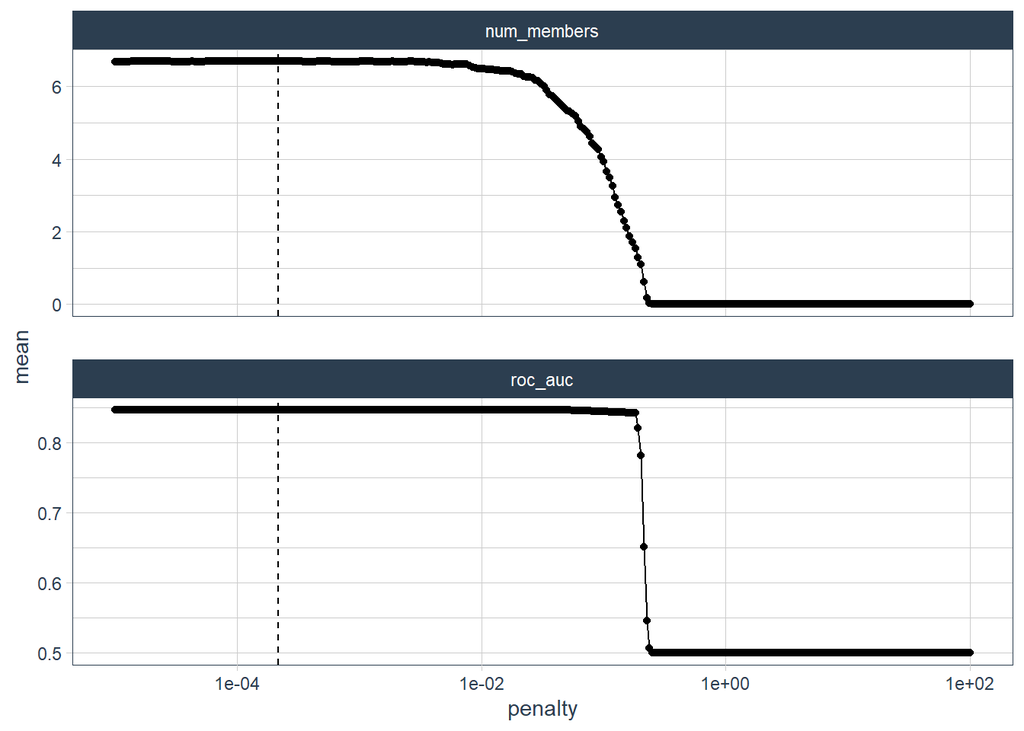

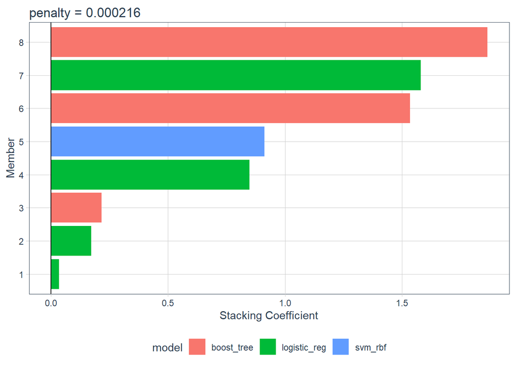

## Model Diagnostics

Model Performance on Dataset

| .metric | Train_Dataset | Test_Dataset |
| --- | --- | --- |
| accuracy | 0.957 | 0.888 |
| roc_auc | 0.980 | 0.843 |
| pr_auc | 0.935 | 0.655 |
| average_precision | 0.935 | 0.658 |
| precision | 0.926 | 0.742 |
| recall | 0.794 | 0.479 |

In analyzing the employee retention project, it’s evident that our model’s performance remains strong on the test dataset, as indicated by an ROC_AUC score exceeding 80%. However, it’s noteworthy that there has been a significant decline of 14% in performance compared to our well-performing training dataset. The most concerning metric in this context is the PR_AUC (Precision-Recall Area Under the Curve), which has exhibited a substantial 28% decrease, resulting in a value of 65% on the test dataset. This disparity might suggest that the model lacks sufficient instances to effectively distinguish between the two states being considered, possibly due to an imbalance in the dataset. Further investigation and potential adjustments are warranted to enhance the model’s precision-recall performance on the test data.

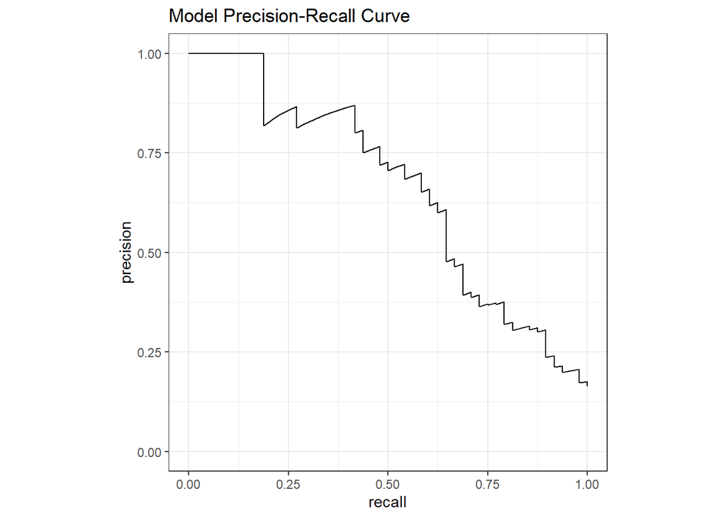

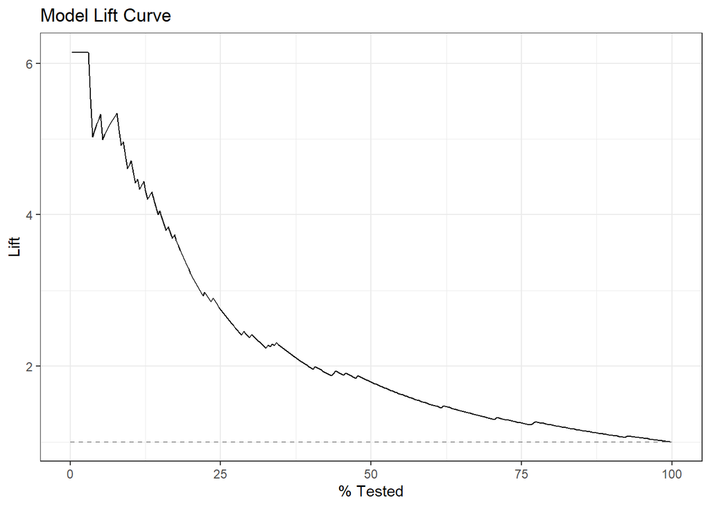

From our lift chart above, it is evident that our models demonstrates significant predictive capability for employee attrition with an uplift as high as over 4 in the first deciles and above 2 in the first two deciles. Throught the deciles, our models surpasses an uplift value of 1, indicating superior performance compared to a random model. This shows that our model possesses strong discriminative power in distinguishing potential churning employee from loyal staffs.

Model Performance on Test dataset

| Decile | Actual | Predicted | Probability | Error_Rate |
| --- | --- | --- | --- | --- |
| 10% | 141 | 147 | 66%-96% | 4%-34% |
| 20% | 61 | 46 | 22%-65% | 35%-78% |
| 30% | 14 | 0 | 12%-22% | 78%-88% |
| 40% | 9 | 0 | 8%-12% | 88%-92% |
| 50% | 6 | 0 | 5%-8% | 92%-95% |
| 60% | 1 | 0 | 4%-5% | 95%-96% |
| 70% | 1 | 0 | 4%-4% | 96%-96% |
| 80% | 3 | 0 | 3%-4% | 96%-97% |
| 90% | 0 | 0 | 3%-3% | 97%-97% |
| 100% | 1 | 0 | 3%-3% | 97%-97% |

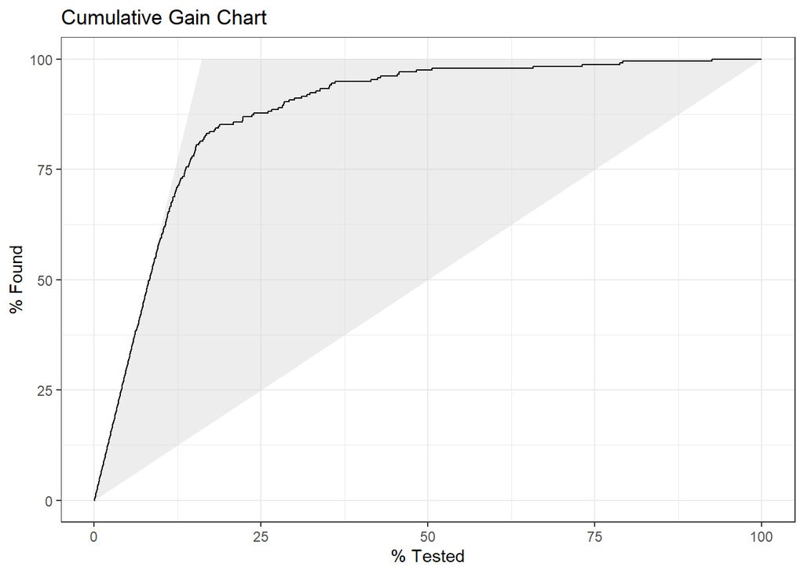

The decile analysis reveals significant insights regarding employee attrition. Decile 1 stands out as the group with the highest likelihood of leaving the company, consisting of 141 employees. Remarkably, this decile contributes to 59% of the total attrition across all the deciles. This means that for just 10% of the total workforce, the organization experiences 59% of its attrition, making it a critical focus area for retention efforts.

To proactively address and significantly reduce employee attrition, the organization should prioritize efforts to retain employees falling within Decile 1 and Decile 2. By implementing targeted retention strategies that address the specific concerns and motivations of these employees, the company can improve overall employee retention rates and create a more stable and engaged workforce.

## Model Explaination

### Variable Importance

The variable importance chart has unequivocally revealed that the “OverTime” metric holds the utmost importance in predicting employee attrition. This suggests that employees who work overtime are more likely to consider leaving the company.Beyond “OverTime,” we have identified several other variables that exhibit substantial predictive capabilities for employee attrition.

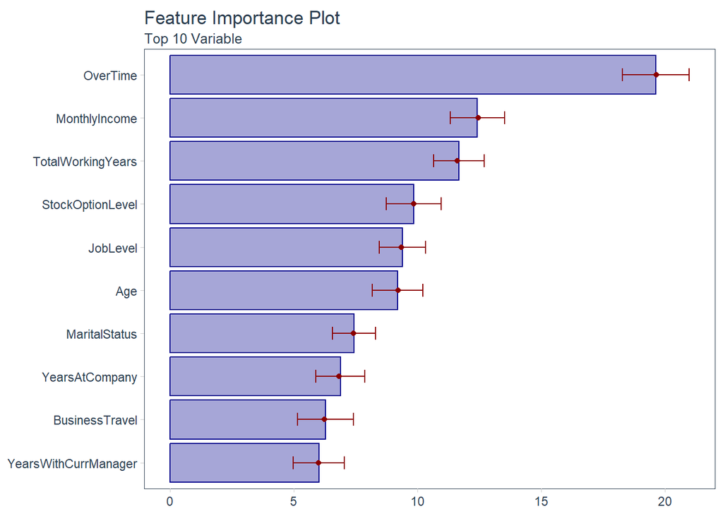

The “MonthlyIncome” of an employee has emerged as the second most influential factor. Employees with lower salaries might be more inclined to seek better-paying opportunities elsewhere.The number of “TotalWorkingYears” holds a significant impact on employee attrition. Employees with longer tenures may seek new challenges or career advancements, and thus, the company could offer growth opportunities, professional development programs, or internal job rotations to retain experienced staff.  
“StockOptionLevel” has proven to be a relevant factor in employee attrition. Employees with higher stock option levels may have a stronger sense of financial security and motivation to stay with the organization. The “Age” of employees and their current “JobLevel” also exhibit considerable predictive power. Older employees or those in higher job levels may be more stable in their positions, leading to lower attrition rates.

## Predictor-Response Relationship

As part of our ongoing employee attrition project, we have undertaken a comprehensive data analysis and modeling exercise to better understand the underlying factors that influence employee attrition within our organization. One of the key techniques that would be utilized to gain insights into our predictive model is the Partial Dependence Profile plot, which provides valuable visualizations of the predictor-response relationships. The following synthesis report highlights significant implications drawn from the analysis of this plot, shedding light on how various factors impact employee attrition

The PDP plot below reveals that younger employees exhibit a substantially higher attrition rate compared to their more experienced counterparts. Notably, the attrition rate starts to decrease significantly from the age of 35 years. This insight suggests that addressing the concerns of younger employees and providing them with ample growth opportunities could potentially reduce attrition rates and foster long-term loyalty within this age group.

Another pivotal finding emerges when examining the relationship between income levels and attrition. The plot demonstrates that employees with lower incomes are more prone to attrition compared to those with higher earnings. This observation implies that remuneration plays a critical role in employee retention, and efforts to enhance compensation packages for lower-income employees could serve as a potential strategy to mitigate attrition in this particular segment.

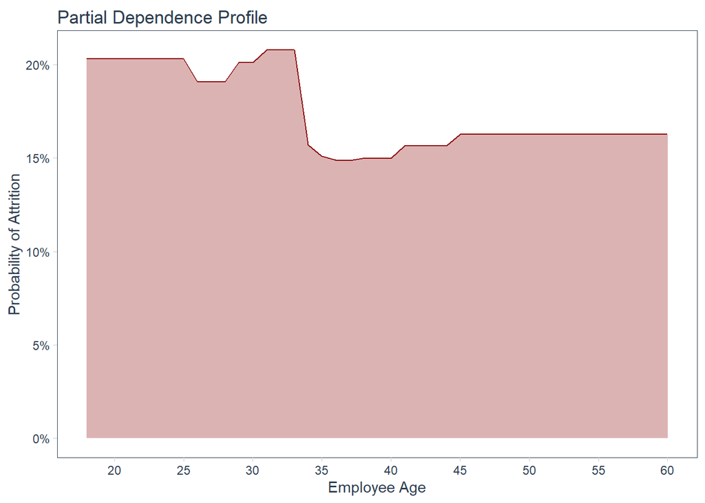

[figure not shown]

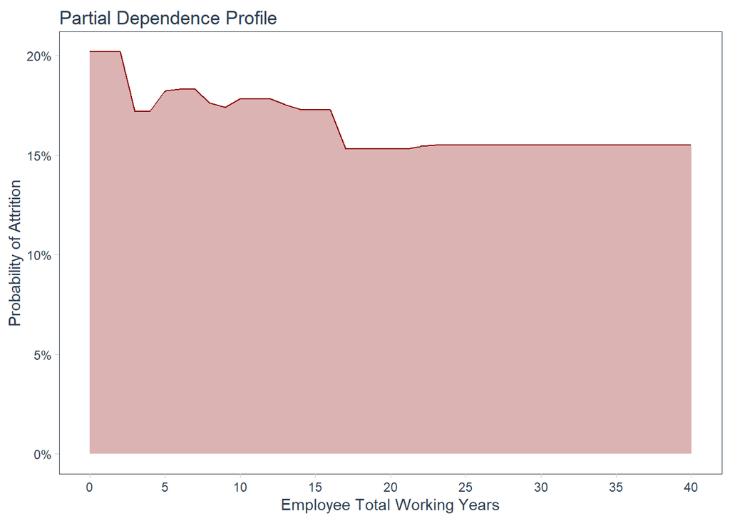

The analysis of the Partial Dependence Profile plot also offers valuable insights regarding the combination of work experience and tenure with the organization. Employees with limited or no prior work experience and who have not completed at least three years with the organization tend to exhibit a higher tendency to attrite. This indicates the significance of providing support, training, and engagement initiatives to new hires and individuals during their initial years of employment to foster a sense of belonging and loyalty within the organization.

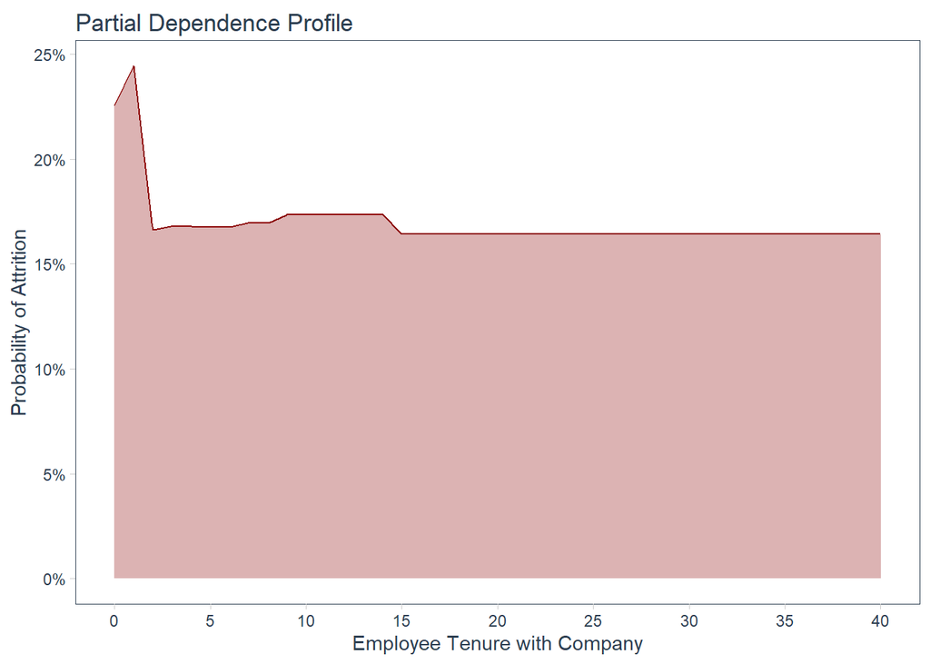

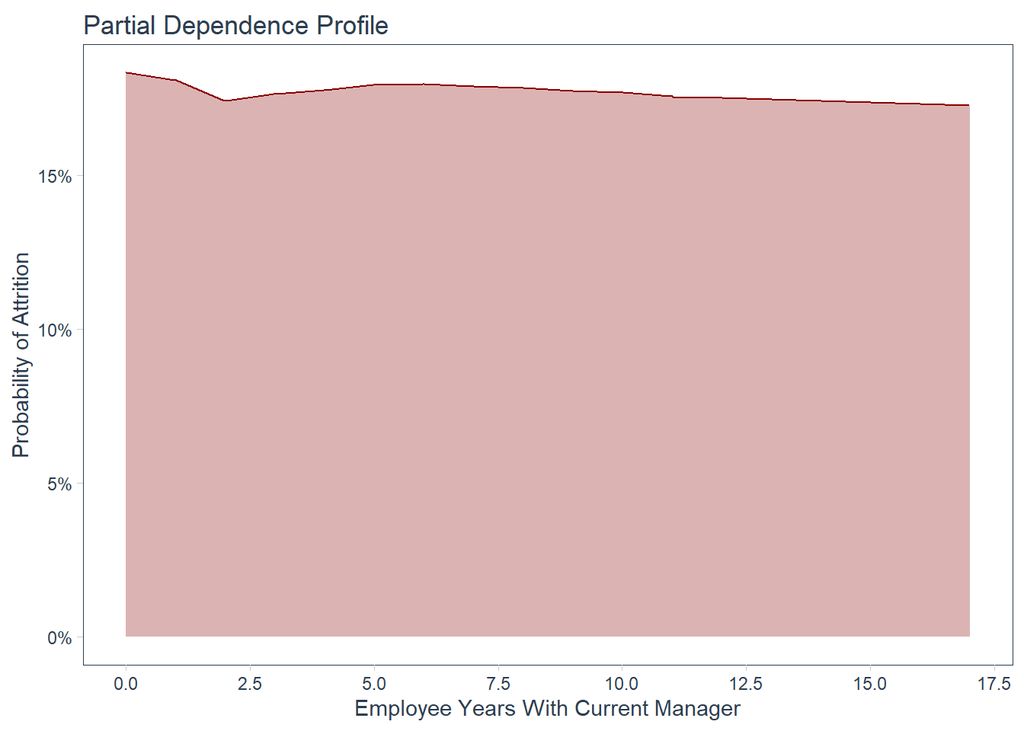

Employees who reported being “very dissatisfied” with the organizational culture and work environment displayed a higher propensity to leave the company. This highlights the importance of fostering a positive and inclusive work environment to retain valuable talent and reduce attrition rates.

Additionally, job level emerged as a key factor affecting attrition. Entry-level, mid-level, and executive-level employees all showed a tendency to attrite, with entry-level employees exhibiting the highest attrition rates. This suggests that addressing factors like limited growth opportunities, job satisfaction, and aligning expectations with reality for early-career employees is crucial in retaining them within the organization.

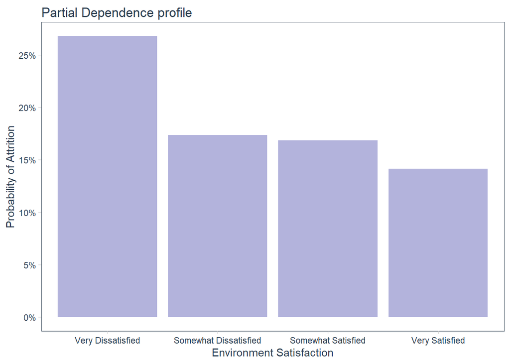

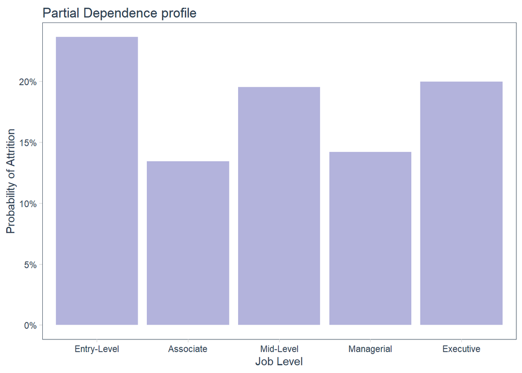

Surprisingly, overtime work also had a significant association with attrition, with employees engaging in overtime more likely to leave compared to those who did not work overtime. This raises concerns about work-life balance and potential burnout, emphasizing the importance of managing work hours and promoting employee well-being to reduce attrition.  
Another noteworthy finding is the impact of marital status on attrition. Single employees were more likely to attrite compared to their married counterparts. The underlying reasons for this observation may be multifaceted, including single individuals being more open to job changes and career advancements or personal life priorities influencing their decision to seek other opportunities.

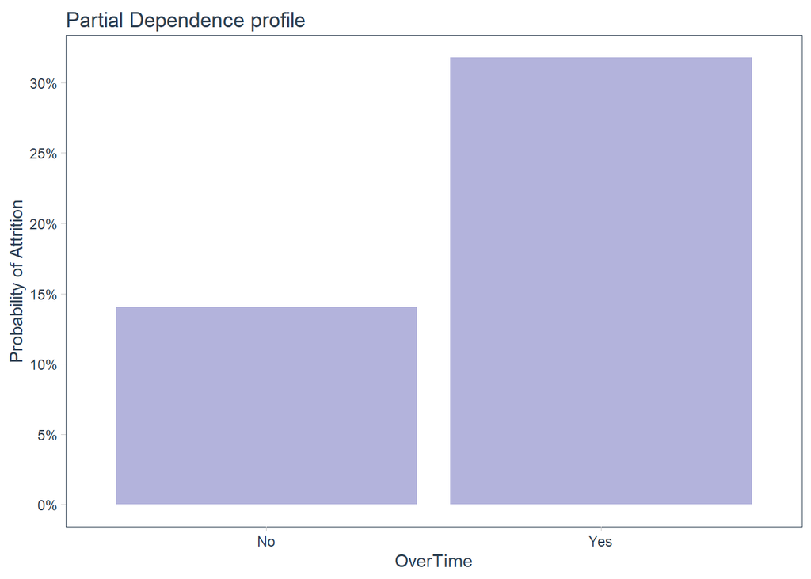

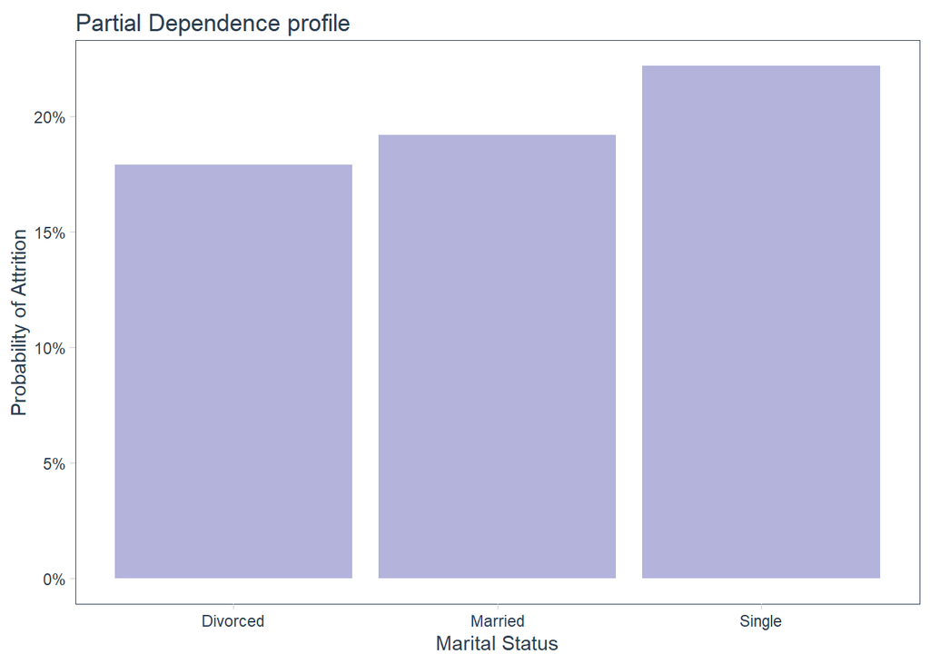

In conclusion, the analysis of the Partial Dependence Profile plot has provided valuable insights into the factors influencing employee attrition within our organization. Several key findings have emerged from this study:

1. Age: Younger employees exhibit a higher attrition rate compared to more experienced ones. Addressing the concerns of younger employees and providing growth opportunities may reduce attrition rates within this age group.
2. Income: Lower-income employees are more prone to attrition. Enhancing compensation packages for this segment could potentially mitigate attrition.
3. Work Experience and Tenure: Employees with limited work experience and those within their initial years with the organization tend to have a higher tendency to attrite. Support, training, and engagement initiatives for new hires are crucial in fostering loyalty.
4. Organizational Culture and Work Environment: Employees who report being “very dissatisfied” with the company’s culture and work environment are more likely to leave. Fostering a positive and inclusive work environment is essential for talent retention.
5. Job Level: Attrition is observed across entry-level, mid-level, and executive-level employees, with entry-level employees having the highest rates. Addressing factors like limited growth opportunities and job satisfaction for early-career employees is vital in retention efforts.
6. Overtime Work: Overtime work is associated with higher attrition rates, raising concerns about work-life balance and potential burnout. Managing work hours and promoting employee well-being can help reduce attrition.
7. Marital Status: Single employees are more likely to attrite compared to married employees. The reasons for this observation may be related to personal life priorities or openness to job changes and career advancements.

To improve employee retention rates, the organization should focus on implementing targeted strategies based on these insights. These strategies may include providing career development opportunities for younger employees, enhancing compensation packages for lower-income employees, offering support and engagement initiatives for new hires, fostering a positive and inclusive work culture, addressing the needs of early-career employees, managing work hours effectively, and considering the potential influence of marital status on attrition.

By addressing these factors, the organization can work towards fostering a more engaged and satisfied workforce, ultimately leading to improved employee retention rates and long-term loyalty within the organization. Continuous monitoring and evaluation of these strategies will be crucial to ensure their effectiveness and adaptability as the company evolves.